# SUPPLY CHAIN ANALYSIS

Yashwanth Velayudham, Kieran Murdocca and Kaiwen Fu

Last Updated: 2023-12-11

**Table of Contents:**

**SECTION 0: Summary of Data and background information:**

**SECTION 1: Availability Vs Price**

**SECTION 2: Revenue Generated and Number of products sold**

**SECTION 3: Based on how many orders are placed how fat the orders are shipped**

**SECTION 4: Basic Table for availibilty and price for all the units**

**SECTION 0: Summary of Data and background information:**

[**About the Dataset:**] Supply chain analytics is a valuable part of data-driven decision-making in various industries such as manufacturing, retail, healthcare, and logistics. It is the process of collecting, analyzing and interpreting data related to the movement of products and services from suppliers to customers. The dataset is based on the supply chain of Makeup products.

[**Questions which are answered below:**]

At what quantity of products ordered and effect on lead time?  
At what is the best for price and effect on generated revenue?  
Which areas can be fixed by targeting locations for improvement in growth or revenue?

**SECTION 1-Availabilty Vs Price**

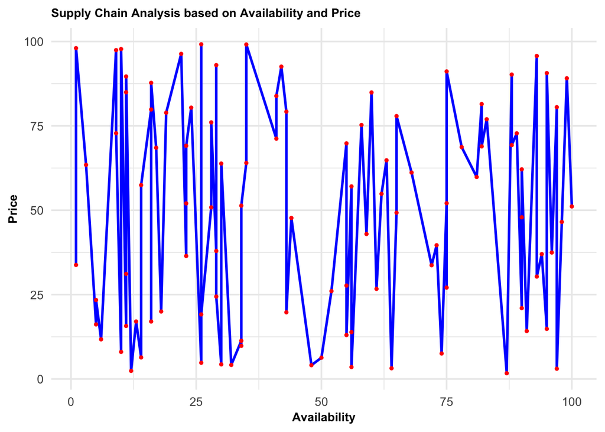

**SECTION 2-Revenue Generated and Number of products sold**

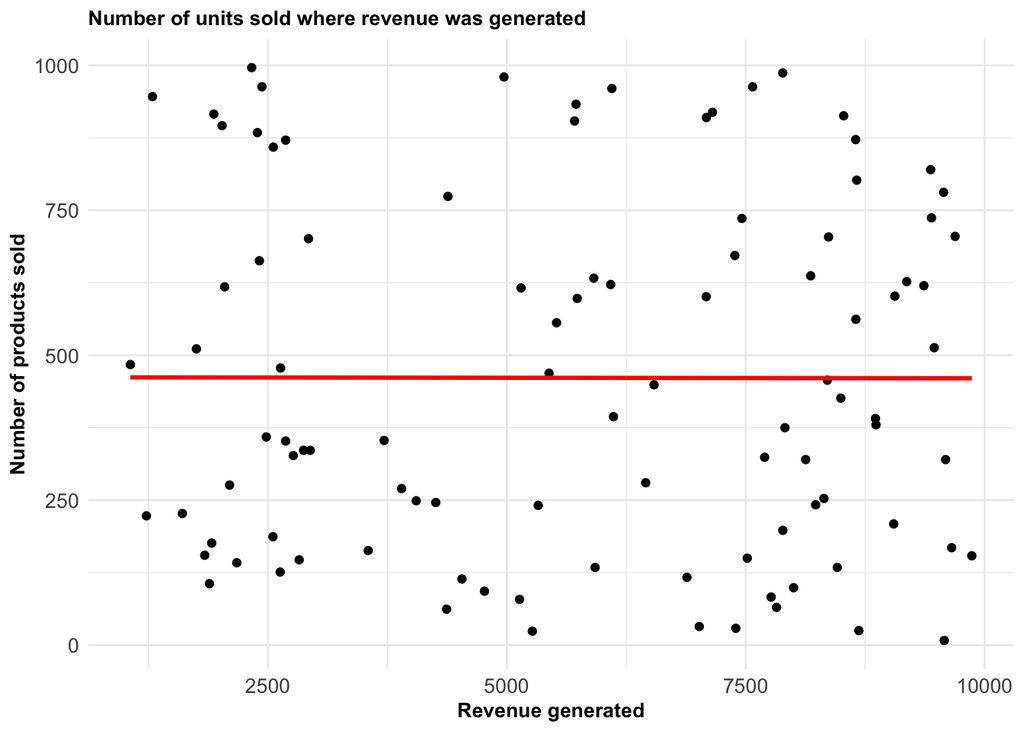

```r
library(ggplot2)

ggplot(supply_chain_data, aes(x = Revenue.generated, y = Number.of.products.sold)) +
  geom_point() +
  geom_smooth(method = "lm", se = FALSE, color = "Red") +
  labs(
    x = "Revenue generated",
    y = "Number of products sold",
    title = "Number of units sold where revenue was generated"

  ) +
  theme_minimal(base_size = 10)+
theme(axis.text = element_text(size = 10),
        axis.title = element_text(size = 10, face = "bold"),
        plot.title = element_text(size = 10, face = "bold"))
```

This scatter plot provides a detailed view of the relationship between revenue generation and the number of products sold. Each point on the graph represents a unique data entry, where the x-axis shows the revenue generated and the y-axis indicates the number of products sold. The plot includes a linear regression line (in red), highlighting the general trend within the data.

**SECTION 3- Based on how many orders are placed how fat the orders are shipped**

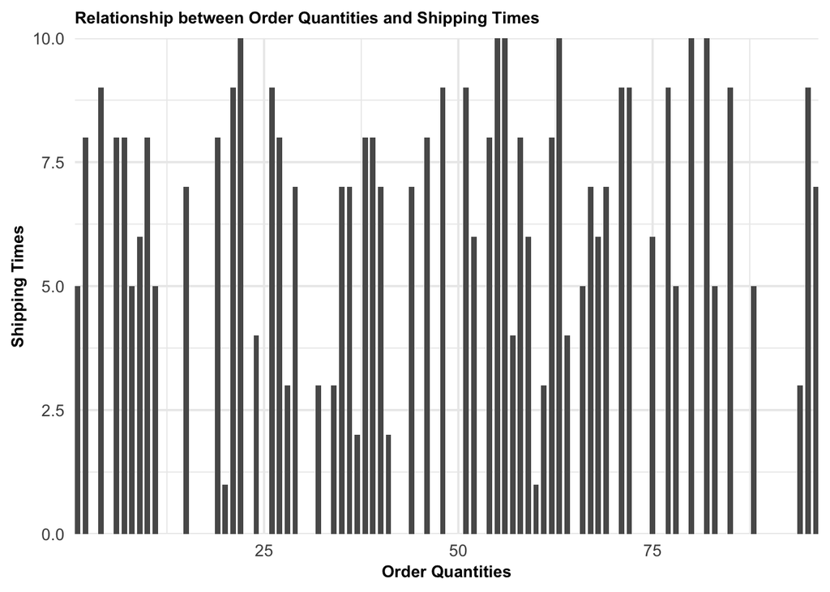

```r
library(ggplot2)

ggplot(supply_chain_data, aes(x = Order.quantities, y = Shipping.times)) +
  geom_bar(stat = "identity", position = "dodge", width = 0.7) +
  labs(
    x = "Order Quantities",
    y = "Shipping Times",
    title = "Relationship between Order Quantities and Shipping Times"
  ) +
  scale_y_continuous(expand = c(0, 0), name = "Shipping Times") +
  scale_x_continuous(expand = c(0, 0), name = "Order Quantities") +
  theme_minimal(base_size = 14) +
  theme(axis.text = element_text(size = 10),
        axis.title = element_text(size = 10, face = "bold"),
        plot.title = element_text(size = 10, face = "bold"))
```

This bar chart is titled “Relationship between Order Quantities and Shipping Times.” The vertical bars represent shipping times for different order quantities. The x-axis shows the order quantities, and it seems to go up to at least 75. The y-axis shows the shipping times, ranging from 0 to 10. The chart shows variability in shipping times across different order quantities. There’s no clear trend that suggests shipping times consistently increase or decrease with larger order quantities. Some small orders have long shipping times, and some large orders have short shipping times. This could mean that the time it takes to ship orders doesn’t depend solely on how many items are ordered. Other factors, like the type of product, destination, or shipping method, might also affect how long it takes for an order to ship.

**SECTION 4- Basic Table for availibilty and price for all the units**

```r
library(ggplot2)
data <- data.frame(

  Product = c("Haircare", "Skincare", "Cosmetics"),
  Availability = c(1332, 1471, 2037),
  Price = c(1491.38,1564.48 ,1890.37)
)
print(data)
```

```
##     Product Availability   Price
## 1  Haircare         1332 1491.38
## 2  Skincare         1471 1564.48
## 3 Cosmetics         2037 1890.37
```

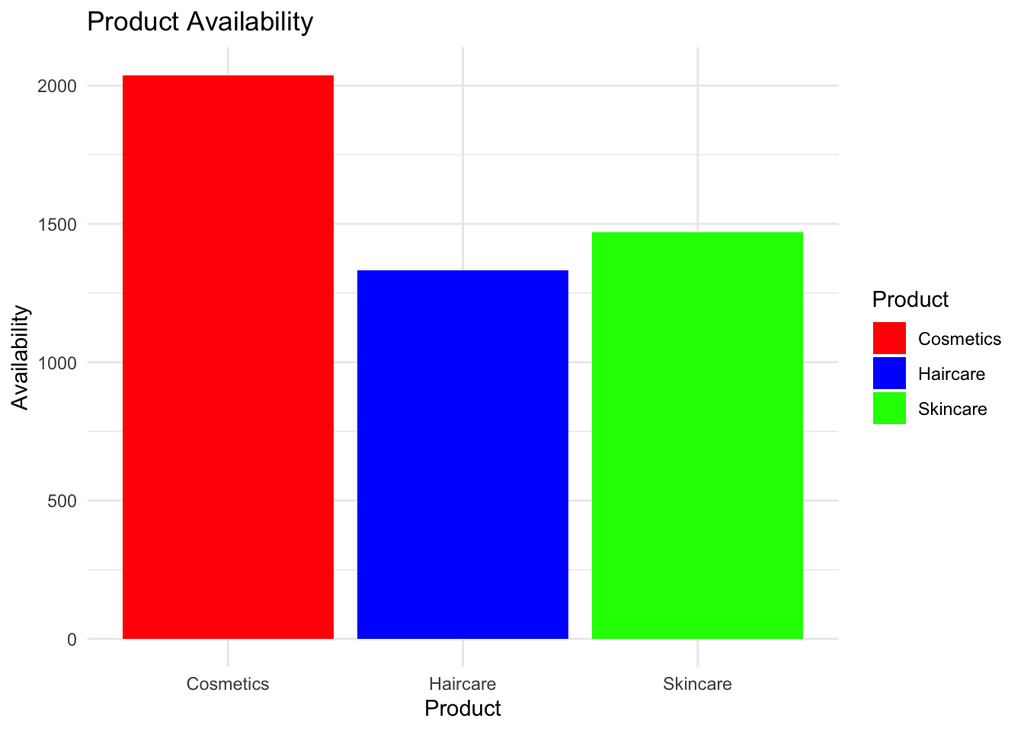

```r
#Cleaned up the data and then put into a an organized bar graph which is organized based on product.
ggplot(data, aes(x = Product, y = Availability, fill = Product)) +
  geom_bar(stat = "identity", position = "dodge") +
  labs(title = "Product Availability",
       x = "Product",
       y = "Availability") +
  scale_fill_manual(values = c("Haircare" = "blue", "Skincare" = "green", "Cosmetics" = "red")) +
  theme_minimal()
```

[figure not shown]